# HW1_Data622

Mahmud Hasan Al Raji

2024-03-20

# Introduction

The main goal of this assignment is to investigate two datasets to identify suitable machine learning algorithms learned so far that can be effectively applied to analyze the data. Furthermore, the assignment seeks to address various inquiries concerning the influence of correlations among variables, categorical labels on algorithm selection, the advantages and disadvantages of the chosen algorithms, the correlation between algorithm choice and dataset characteristics, the reliability of results for making business decisions, and the possibility of errors in the analysis.

In this assignment, I have used two datasets collected from Kaggle.com, both containing information on housing prices in the USA. The reason behind choosing these datasets was to predict house prices, understand the dynamics of factors affecting them, and gain insights into the importance of selecting modeling techniques applicable to dataset characteristics. The dataset links are: https://www.kaggle.com/datasets/neerajkld/realtor-real-estate-usa?resource=download, and https://www.kaggle.com/code/syedali110/house-price-prediction-and-visualization/input.

# Required libraries

```r
library(dplyr)
```

```r
library(ggplot2)
library(rpart)
library(rpart.plot)
library(caret)
library(randomForest)
```

# Get the first dataset

```r
house_price1<-read.csv("F:\\CUNY masters\\Data 622\\HW1\\realtor-data.zip.csv",header=TRUE,sep=",")
```

# Data exploration

```r
# See first house price dataset at a glance
glimpse(house_price1)
```

```
## Rows: 110,101
## Columns: 10
## $ status         <chr> "for_sale", "for_sale", "for_sale", "for_sale", "for_sa…
## $ bed            <int> 3, 4, 2, 4, 6, 4, 3, 3, 2, 5, 3, 3, 3, 5, 5, 3, 4, 3, 3…
## $ bath           <int> 2, 2, 1, 2, 2, 3, 1, 2, 1, 3, 2, 2, 2, 2, 5, 2, 4, 2, 2…
## $ acre_lot       <dbl> 0.12, 0.08, 0.15, 0.10, 0.05, 0.46, 0.20, 0.08, 0.09, 7…
## $ city           <chr> "Adjuntas", "Adjuntas", "Juana Diaz", "Ponce", "Mayague…
## $ state          <chr> "Puerto Rico", "Puerto Rico", "Puerto Rico", "Puerto Ri…
## $ zip_code       <int> 601, 601, 795, 731, 680, 612, 639, 731, 730, 670, 662, …
## $ house_size     <int> 920, 1527, 748, 1800, NA, 2520, 2040, 1050, 1092, 5403,…
## $ prev_sold_date <chr> NA, NA, NA, NA, NA, NA, NA, NA, NA, NA, NA, NA, NA, NA,…
## $ price          <int> 105000, 80000, 67000, 145000, 65000, 179000, 50000, 716…
```

```r
# Summary statistics of the first house price dataset
print(summary(house_price1))
```

```
##     status               bed               bath            acre_lot
##  Length:110101      Min.   :  1.000   Min.   :  1.000   Min.   :     0.00
##  Class :character   1st Qu.:  2.000   1st Qu.:  2.000   1st Qu.:     0.11
##  Mode  :character   Median :  3.000   Median :  2.000   Median :     0.26
##                     Mean   :  3.314   Mean   :  2.518   Mean   :    18.18
##                     3rd Qu.:  4.000   3rd Qu.:  3.000   3rd Qu.:     1.03
##                     Max.   :123.000   Max.   :198.000   Max.   :100000.00
##                     NA's   :16770     NA's   :15586     NA's   :29882
##      city              state              zip_code       house_size
##  Length:110101      Length:110101      Min.   :  601   Min.   :    100
##  Class :character   Class :character   1st Qu.: 5903   1st Qu.:   1152
##  Mode  :character   Mode  :character   Median : 7932   Median :   1660
##                                        Mean   : 8225   Mean   :   2158
##                                        3rd Qu.:10065   3rd Qu.:   2494
##                                        Max.   :99999   Max.   :1450112
##                                        NA's   :32      NA's   :35311
##  prev_sold_date         price
##  Length:110101      Min.   :        0
##  Class :character   1st Qu.:   250000
##  Mode  :character   Median :   449900
##                     Mean   :   914077
##                     3rd Qu.:   800000
##                     Max.   :875000000
##                     NA's   :18
```

```r
# See missing values in  the first dataset separately
missing_values <- colSums(is.na(house_price1))
print(missing_values)
```

```
##         status            bed           bath       acre_lot           city
##              0          16770          15586          29882             22
##          state       zip_code     house_size prev_sold_date          price
##              0             32          35311          51883             18
```

```r
unique_states<-unique(house_price1$state)
print(unique_states)
```

```
##  [1] "Puerto Rico"    "Virgin Islands" "Massachusetts"  "Connecticut"
##  [5] "New Hampshire"  "Vermont"        "New Jersey"     "New York"
##  [9] "South Carolina" "Tennessee"      "Rhode Island"   "Virginia"
## [13] "Wyoming"        "Maine"          "Georgia"        "Pennsylvania"
## [17] "West Virginia"  "Delaware"
```

```r
num_unique_states <- length(unique_states)
print(num_unique_states)
```

```
## [1] 18
```

```r
unique_city<-unique(house_price1$city)
#unique_city

num_unique_city <- length(unique_city)
print(num_unique_city)
```

```
## [1] 2488
```

```r
unique_status<-unique(house_price1$status)
unique_status
```

```
## [1] "for_sale"       "ready_to_build"
```

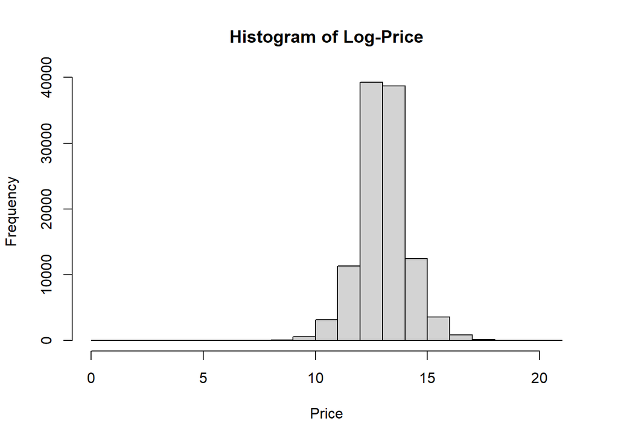

```r
# Plot histogram of the target variable 'price' of the first dataset
log_price<-log(house_price1$price)
hist(log_price,
     main = "Histogram of Log-Price",
     xlab = "Price",
     ylab = "Frequency")
```

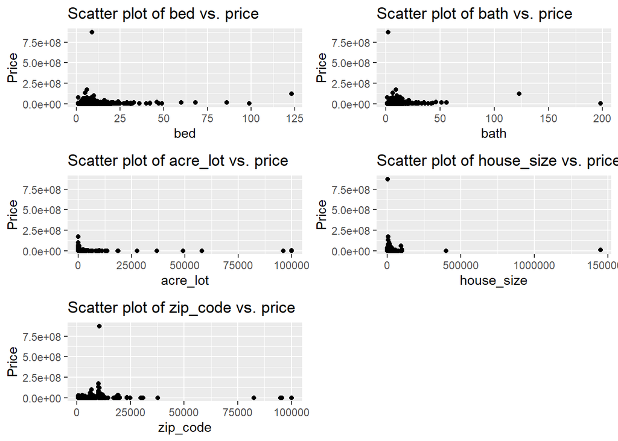

```r
# Select numerical predictors from the first dataset
numerical_predictors <- c("bed", "bath", "acre_lot", "house_size","zip_code")

# Create matrix layout for plots
plot_matrix <- lapply(numerical_predictors, function(predictor) {
  ggplot(house_price1, aes_string(x = predictor, y = "price")) +
    geom_point() +
    labs(title = paste("Scatter plot of", predictor, "vs. price"),
         x = predictor,
         y = "Price")
})
# Create scatter plots in a single plot
gridExtra::grid.arrange(grobs = plot_matrix, ncol = 2)
```

No linear relationships observed among numerical predictors and target variable. Also, the distribution of the target variable, price in logarithm scale found left skewed.

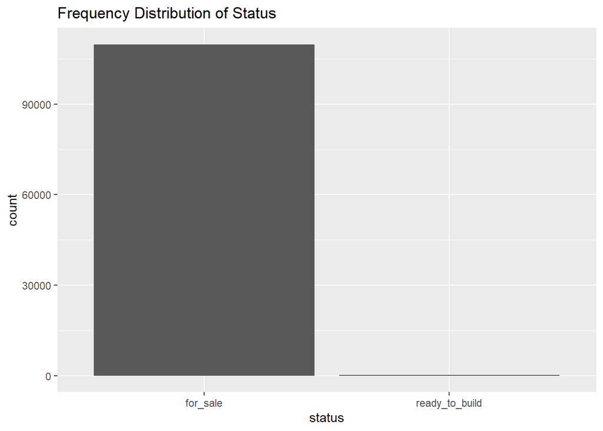

```r
# Plot frequency distribution of categorical variables: status, city and state
ggplot(house_price1, aes(x = status)) +
  geom_bar() +
  labs(title = "Frequency Distribution of Status")
```

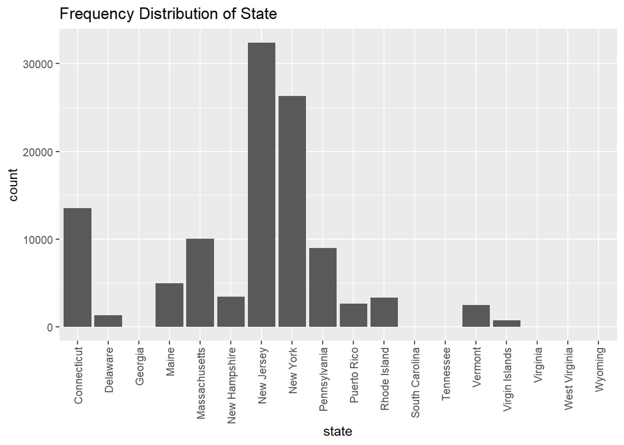

```r
#ggplot(house_price1, aes(x = city)) +
 # geom_bar() +
  #labs(title = "Frequency Distribution of City")+
#theme(axis.text.x = element_text(angle = 90, vjust = 0.5, hjust=1))

ggplot(house_price1, aes(x = state)) +
  geom_bar() +
  labs(title = "Frequency Distribution of State")+
theme(axis.text.x = element_text(angle = 90, vjust = 0.5, hjust=1))
```

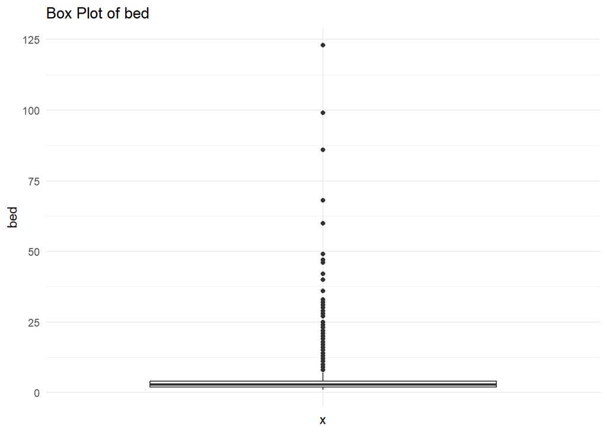

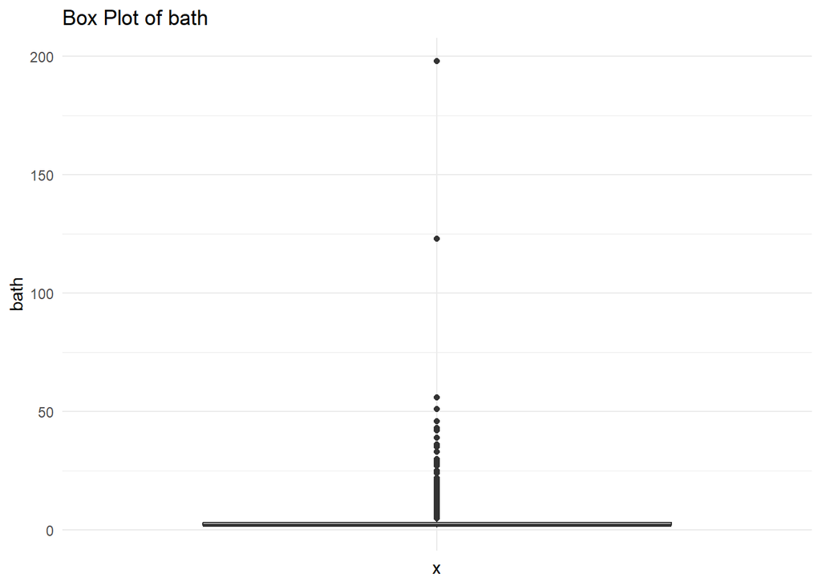

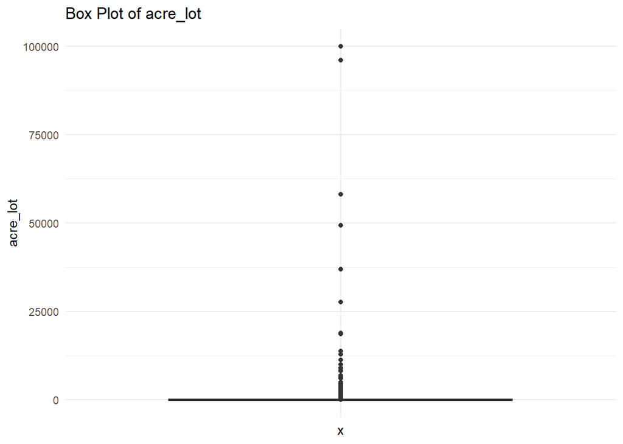

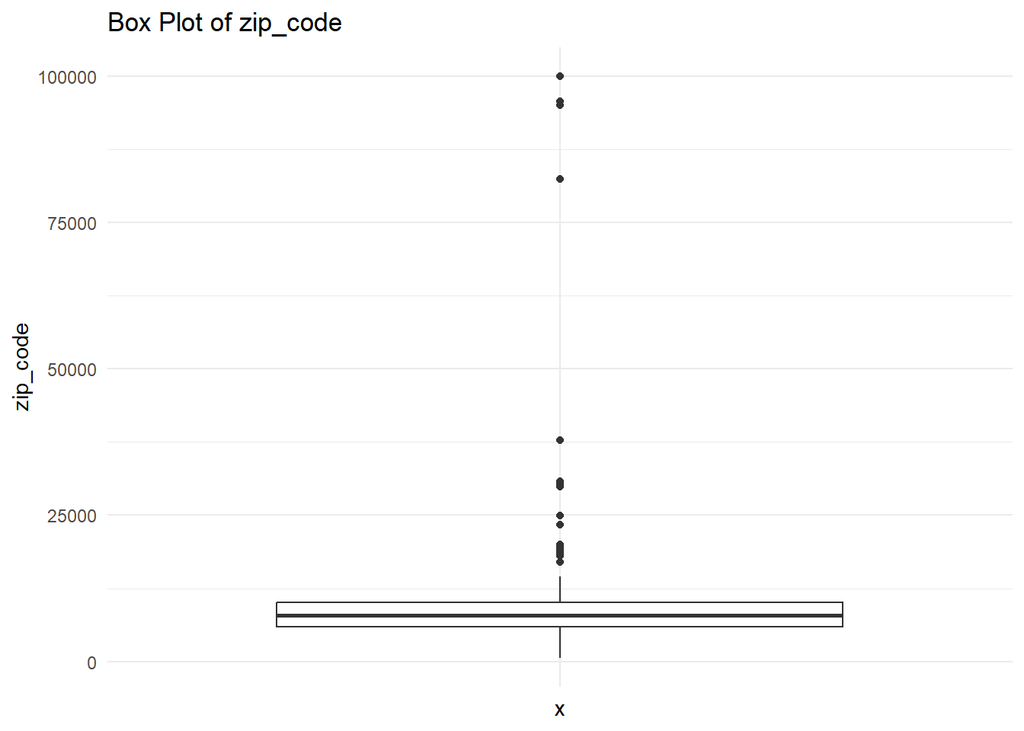

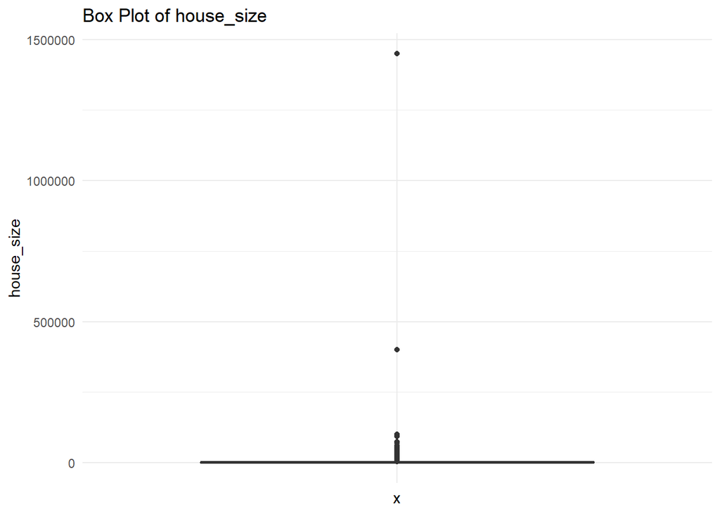

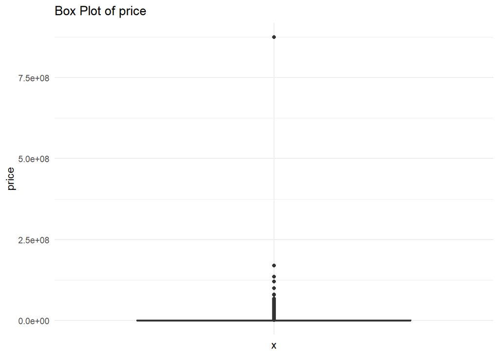

```r
## Checking outliers

# Specify numerical predictors
numeric_predictors01 <- c("bed", "bath", "acre_lot", "zip_code", "house_size", "price")

# Create box plots for each numerical predictor
for (predictor in numeric_predictors01) {
  p<-ggplot(house_price1, aes(x = "", y = house_price1[[predictor]])) +
    geom_boxplot() +
    labs(title = paste("Box Plot of", predictor),
         y = predictor) +
    theme_minimal() +
    theme(axis.text.x=element_blank())
print(p)
}
```

The wide spread of each numerical variable suggests the presence of potential outliers. However, it’s important to note that this type of spread is common in real estate data from Realtor. Realtor listings encompass not only typical residential houses but also include commercial properties, vacant lands, and more, which can contribute to such variability. Therefore, all the data points will be kept in this analysis.

# Cehcking correlations among predictors

```r
# Specify numerical predictors
numeric_predictors1 <- house_price1[, c("bed", "bath", "acre_lot", "house_size", "zip_code")]

# Calculate correlation matrix
cor_matrix <- cor(is.na(numeric_predictors1))

# See correlation matrix
print(cor_matrix)
```

```
##                    bed        bath     acre_lot  house_size     zip_code
## bed         1.00000000  0.87518965 -0.123657639  0.50302087  0.023912723
## bath        0.87518965  1.00000000 -0.194060281  0.49034982  0.023646005
## acre_lot   -0.12365764 -0.19406028  1.000000000 -0.03000117 -0.005613674
## house_size  0.50302087  0.49034982 -0.030001167  1.00000000  0.011115732
## zip_code    0.02391272  0.02364601 -0.005613674  0.01111573  1.000000000
```

# Data preparation

```r
# Remove prev_sold_date column
house_price <- subset(house_price1, select = -prev_sold_date)

# See missing values
missing_values1 <- colSums(is.na(house_price))
print(missing_values1)
```

```
##     status        bed       bath   acre_lot       city      state   zip_code
##          0      16770      15586      29882         22          0         32
## house_size      price
##      35311         18
```

```r
# Remove rows with missing values in specified columns
house_price <- house_price[complete.cases(house_price$city, house_price$zip_code, house_price$price), ]

# Calculate mean values for bed, bath, acre_lot and house_size variables
mean_bed <- mean(house_price$bed, na.rm = TRUE)
mean_bath <- mean(house_price$bath, na.rm = TRUE)
mean_acre_lot <- mean(house_price$acre_lot, na.rm = TRUE)
mean_house_size <- mean(house_price$house_size, na.rm = TRUE)

# Replace missing values with mean values
house_price$bed[is.na(house_price$bed)] <- mean_bed
house_price$bath[is.na(house_price$bath)] <- mean_bath
house_price$acre_lot[is.na(house_price$acre_lot)] <- mean_acre_lot
house_price$house_size[is.na(house_price$house_size)] <- mean_house_size

# See missing values again
missing_values2 <- colSums(is.na(house_price))
print(missing_values2)
```

```
##     status        bed       bath   acre_lot       city      state   zip_code
##          0          0          0          0          0          0          0
## house_size      price
##          0          0
```

```r
## Now the dataset is ready for modeling
head(house_price)
```

```
##     status bed bath acre_lot          city       state zip_code house_size
## 1 for_sale   3    2     0.12      Adjuntas Puerto Rico      601     920.00
## 2 for_sale   4    2     0.08      Adjuntas Puerto Rico      601    1527.00
## 3 for_sale   2    1     0.15    Juana Diaz Puerto Rico      795     748.00
## 4 for_sale   4    2     0.10         Ponce Puerto Rico      731    1800.00
## 5 for_sale   6    2     0.05      Mayaguez Puerto Rico      680    2158.08
## 6 for_sale   4    3     0.46 San Sebastian Puerto Rico      612    2520.00
##    price
## 1 105000
## 2  80000
## 3  67000
## 4 145000
## 5  65000
## 6 179000
```

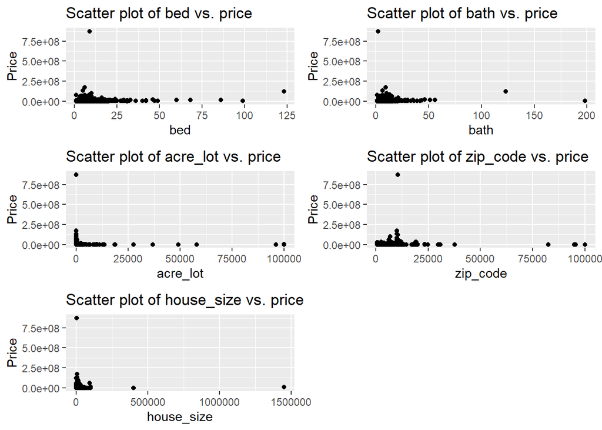

```r
# Specify numerical predictors
numerical_predictors1 <- c("bed", "bath", "acre_lot","zip_code","house_size")

# Create a matrix layout for plots
plot_matrix1 <- lapply(numerical_predictors1, function(predictor) {
  ggplot(house_price, aes_string(x = predictor, y = "price")) +
    geom_point() +
    labs(title = paste("Scatter plot of", predictor, "vs. price"),
         x = predictor,
         y = "Price")
})

# Plot scatter plots in a single plot
gridExtra::grid.arrange(grobs = plot_matrix1, ncol = 2)
```

After imputing missing values, scatter plots for numerical are plotted again. There is no evidence of linear relationships found between various predictors and the target variable, rather, complex nonlinear relationships are found. Therefore, linear regression modeling will not be appropriate for predicting housing prices. In this case, a decision tree/random forest model is a good choice to create to capture the complex non-linear relationships between the predictors and the target variable.

```r
# Select numerical variables
numeric_vars2 <- house_price[, c("bed", "bath", "acre_lot", "house_size", "zip_code")]

# Calculate correlation matrix
cor_matrix2 <- cor(numeric_vars2, use = "pairwise.complete.obs")
print(cor_matrix2)
```

```
##                     bed         bath     acre_lot  house_size     zip_code
## bed         1.000000000  0.695614838 -0.003607916  0.15993786 -0.059383121
## bath        0.695614838  1.000000000 -0.000736314  0.18169524 -0.053327055
## acre_lot   -0.003607916 -0.000736314  1.000000000  0.02106401 -0.004107211
## house_size  0.159937863  0.181695236  0.021064014  1.00000000 -0.024552660
## zip_code   -0.059383121 -0.053327055 -0.004107211 -0.02455266  1.000000000
```

```r
#glimpse(house_price)
```

After imputing missing values, correlation coefficients among predictors are determined again. Only, a strong positive correlation is found between the number of beds and the number of baths. No other significant correlations are found among other predictors.

# Split data into train and test datasets

```r
# Set seed
set.seed(123)

# Split the data into training (70%) and testing (30%) sets
train_index <- createDataPartition(house_price$price, p = 0.70, list = FALSE)
train_data <- house_price[train_index, ]
test_data <- house_price[-train_index, ]
```

The first dataset is divided into training and testing sets using a 70-30 split ratio. Two models, one decision tree, and one random forest, will be constructed using the training data.

# Build models and make predictions

```r
## Build decision tree model

#model1 <- rpart(price ~ status + bed + bath + acre_lot + city + state + zip_code + house_size, data = train_data)

#model1 <- rpart(price ~ status + bed + bath + acre_lot + state + zip_code + house_size, data = train_data)

model1 <- rpart(price ~ status + bed + bath + acre_lot + zip_code + house_size, data = train_data)

# Make predictions on test dataset
dt_predictions <- predict(model1, test_data)

### Error in model.frame.default(Terms, newdata, na.action = na.action, xlev = attr(object,  :
## factor city has new levels Absecon Highlands, Allenwood, Annandale, Bass River, Berkeley Township, Black Brook, Bowdoin, Brig

###Error in model.frame.default(Terms, newdata, na.action = na.action, xlev = attr(object,  :
  ##factor state has new levels Tennesse
```

```r
# Build random forest model
model <- randomForest(price ~ status + bed + bath + acre_lot +city+ state + zip_code + house_size, data = train_data)

# Make predictions on test dataset
rf_predictions1 <- predict(model, test_data)
```

# Model Evaluation:

```r
## Evaluate decision tree model

# Calculate mean absolute error
mae1 <- mean(abs(dt_predictions - test_data$price))
print(paste("Decision tree Mean Absolute Error:", mae1))
```

```
## [1] "Decision tree Mean Absolute Error: 637558.844641793"
```

```r
# Calculate RMSE
rmse1 <- sqrt(mean((dt_predictions - test_data$price)^2))
print(paste("Decision tree Root Mean Squared Error (RMSE):", rmse1))
```

```
## [1] "Decision tree Root Mean Squared Error (RMSE): 2265778.92009352"
```

```r
# Calculate R-squared
dt_r_squared <- cor(dt_predictions, test_data$price)^2
print(paste("Decision tree R-Squared:", dt_r_squared))
```

```
## [1] "Decision tree R-Squared: 0.144690576529264"
```

```r
## Evaluate random forest model

# Calculate mean absolute error
rf1_mae <- mean(abs(rf_predictions1 - test_data$price))
print(paste("Random Forest Mean Absolute Error:", rf1_mae))
```

```
## [1] "Random Forest Mean Absolute Error: 377742.139592903"
```

```r
# Calculate RMSE
rf1_rmse <- sqrt(mean((rf_predictions1 - test_data$price)^2))
print(paste("Random Forest Root Mean Squared Error (RMSE):", rf1_rmse))
```

```
## [1] "Random Forest Root Mean Squared Error (RMSE): 1737733.74799667"
```

```r
# Calculate R-squared
rf1_r_squared <- cor(rf_predictions1, test_data$price)^2
print(paste("Random Forest R-Squared:", rf1_r_squared))
```

```
## [1] "Random Forest R-Squared: 0.420777221348384"
```

Based on the performance metrics, the random forest model outperforms the decision tree model. It achieves a lower Mean Absolute Error (MAE) compared to the decision tree model. Similarly, the Root Mean Squared Error (RMSE) is found substantially lower for the random forest model compared to the decision tree model. Additionally, the random forest model exhibits a higher R-Squared value compared to the decision tree, indicating better explanatory power. Therefore, the random forest model is found to be more reliable for business use due to its superior predictive performance.

# Get second dataset

```r
house_price_data02<-read.csv("F:\\CUNY masters\\Data 622\\HW1\\USA_Housing.csv",header=TRUE,sep=",")
#head(house_price_data02)
```

# Second dataset exploration

```r
glimpse(house_price_data02)
```

```
## Rows: 5,000
## Columns: 7
## $ Avg..Area.Income             <dbl> 79545.46, 79248.64, 61287.07, 63345.24, 5…
## $ Avg..Area.House.Age          <dbl> 5.682861, 6.002900, 5.865890, 7.188236, 5…
## $ Avg..Area.Number.of.Rooms    <dbl> 7.009188, 6.730821, 8.512727, 5.586729, 7…
## $ Avg..Area.Number.of.Bedrooms <dbl> 4.09, 3.09, 5.13, 3.26, 4.23, 4.04, 3.41,…
## $ Area.Population              <dbl> 23086.80, 40173.07, 36882.16, 34310.24, 2…
## $ Price                        <dbl> 1059033.6, 1505890.9, 1058988.0, 1260616.…
## $ Address                      <chr> "208 Michael Ferry Apt. 674\nLaurabury, N…
```

```r
# Summary statistics of the data
print(summary(house_price_data02))
```

```
##  Avg..Area.Income Avg..Area.House.Age Avg..Area.Number.of.Rooms
##  Min.   : 17797   Min.   :2.644       Min.   : 3.236
##  1st Qu.: 61481   1st Qu.:5.322       1st Qu.: 6.299
##  Median : 68804   Median :5.970       Median : 7.003
##  Mean   : 68583   Mean   :5.977       Mean   : 6.988
##  3rd Qu.: 75783   3rd Qu.:6.651       3rd Qu.: 7.666
##  Max.   :107702   Max.   :9.519       Max.   :10.760
##  Avg..Area.Number.of.Bedrooms Area.Population       Price
##  Min.   :2.000                Min.   :  172.6   Min.   :  15939
##  1st Qu.:3.140                1st Qu.:29403.9   1st Qu.: 997577
##  Median :4.050                Median :36199.4   Median :1232669
##  Mean   :3.981                Mean   :36163.5   Mean   :1232073
##  3rd Qu.:4.490                3rd Qu.:42861.3   3rd Qu.:1471210
##  Max.   :6.500                Max.   :69621.7   Max.   :2469066
##    Address
##  Length:5000
##  Class :character
##  Mode  :character
##
##
##
```

```r
# See missing values separately
missing_values02 <- colSums(is.na(house_price_data02))
print(missing_values02)
```

```
##             Avg..Area.Income          Avg..Area.House.Age
##                            0                            0
##    Avg..Area.Number.of.Rooms Avg..Area.Number.of.Bedrooms
##                            0                            0
##              Area.Population                        Price
##                            0                            0
##                      Address
##                            0
```

```r
num_label<-print(length(unique(house_price_data02$Address)))
```

```
## [1] 5000
```

The dataset has 5000 rows and 7 columns (variables). The dataset contains 6 numerical variables and one categorical variable with 5000 distinct labels (addresses). The dataset summary reveals significant variation across multiple variables. The Avg. Area Income ranges from 17,797 US dollar to 107,702 US dollar with an average of 68,583 US dollar, the Avg. Area House Age ranges from 2.64 to 9.52 years, with an average of 5.98 years, the Avg. Area Number of Rooms fluctuates from 3.24 to 10.76, averaging around 6.988 rooms. Also, the Avg. Area Number of Bedrooms ranges from 2.0 to 6.50 with an average of 3.98 bedrooms, the Area Population varies widely from 172.60 to 69,621.70 residents, averaging about 36,163.50. Moreover, the house prices exhibit a broad range, from 15,94 US dollar to 2,469,066 US dollar with an average of approximately 1,232,073 US dollar. Additionally, no missing values found in the the second dataset.

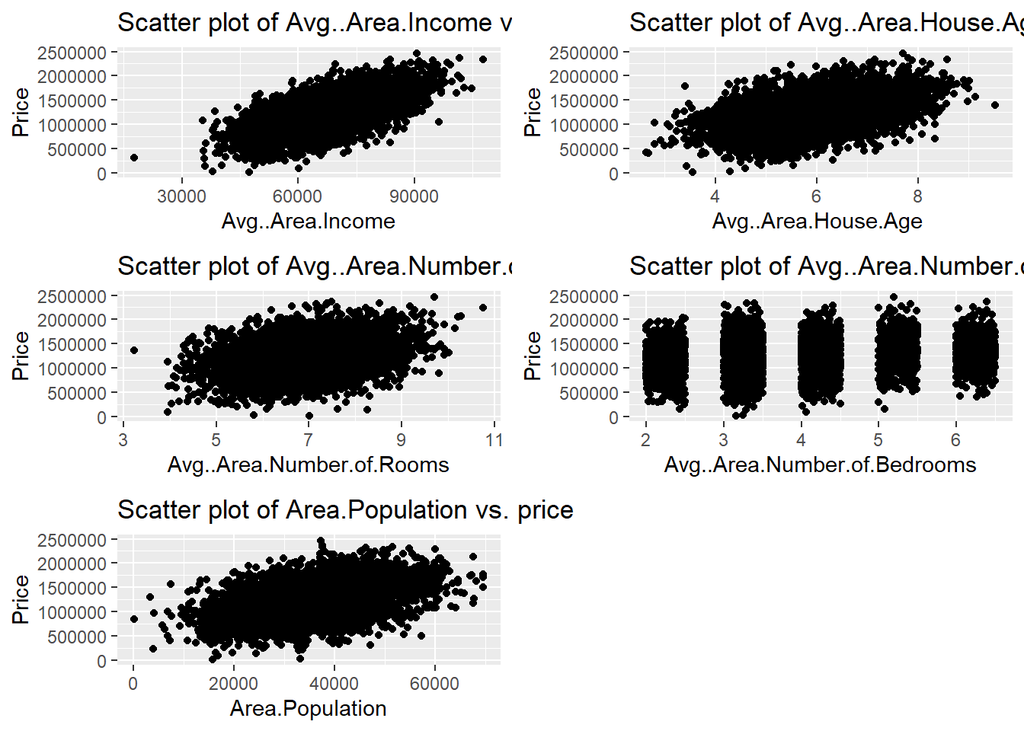

```r
# Specify numerical predictors
numerical_predictors2 <- c("Avg..Area.Income", "Avg..Area.House.Age ", "Avg..Area.Number.of.Rooms", "Avg..Area.Number.of.Bedrooms", "Area.Population")

# Create matrix layout for the plots
plot_matrix2 <- lapply(numerical_predictors2, function(predictor) {
  ggplot(house_price_data02, aes_string(x = predictor, y = "Price")) +
    geom_point() +
    labs(title = paste("Scatter plot of", predictor, "vs. price"),
         x = predictor,
         y = "Price")
})

# Plot scatter plots in a single plot
gridExtra::grid.arrange(grobs = plot_matrix2, ncol = 2)
```

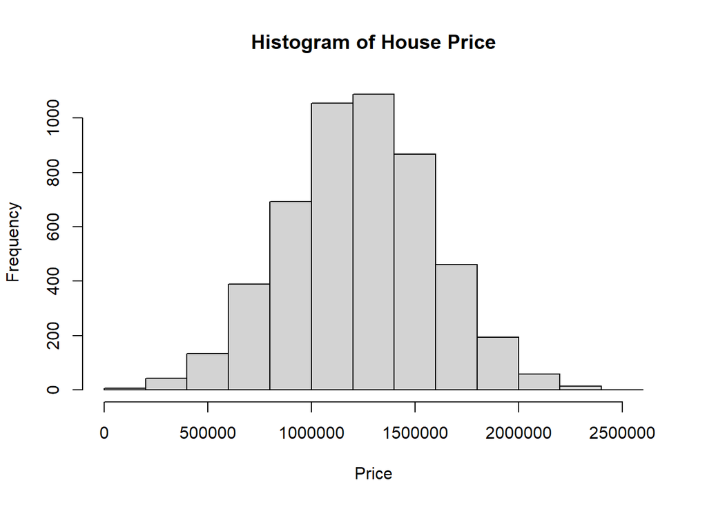

```r
# Plot histogram for target variable, Price
hist(house_price_data02$Price,main = "Histogram of House Price", xlab = "Price", ylab = "Frequency")
```

The scatter plots for numerical variables (predictors) exhibit linear relationships with the target variable, price, except the variable: average area number of number of bedrooms.This variable exhibits clustered data points indicating a complex and non-linear relationship with the target variable.This time I will build a multiple linear regression model and a random forest model to capture the relationships between predictors and the target variable. Also, I will try to understand which model works well with the underlying relationships and complexity of this data.

```r
# Select predictors of interest
numeric_predictors <- c("Avg..Area.Income", "Avg..Area.House.Age", "Avg..Area.Number.of.Rooms",
                "Avg..Area.Number.of.Bedrooms", "Area.Population")

# Determine correlation matrix
corr_matrix02<- cor(house_price_data02[numeric_predictors])

# See correlation matrix
print(corr_matrix02)
```

```
##                              Avg..Area.Income Avg..Area.House.Age
## Avg..Area.Income                  1.000000000        -0.002006826
## Avg..Area.House.Age              -0.002006826         1.000000000
## Avg..Area.Number.of.Rooms        -0.011031660        -0.009428292
## Avg..Area.Number.of.Bedrooms      0.019788221         0.006148923
## Area.Population                  -0.016233740        -0.018742762
##                              Avg..Area.Number.of.Rooms
## Avg..Area.Income                          -0.011031660
## Avg..Area.House.Age                       -0.009428292
## Avg..Area.Number.of.Rooms                  1.000000000
## Avg..Area.Number.of.Bedrooms               0.462694860
## Area.Population                            0.002039928
##                              Avg..Area.Number.of.Bedrooms Area.Population
## Avg..Area.Income                              0.019788221    -0.016233740
## Avg..Area.House.Age                           0.006148923    -0.018742762
## Avg..Area.Number.of.Rooms                     0.462694860     0.002039928
## Avg..Area.Number.of.Bedrooms                  1.000000000    -0.022167642
## Area.Population                              -0.022167642     1.000000000
```

A moderately strong positive linear relationship is found between the average number of bedrooms and average number of rooms. No other significant correlations are found among other predictors reflecting absence of significant multi-collinearity in the data.

# Data Preparation:

```r
# Rename columns
house_price_data02 <- house_price_data02 %>%
  rename(avg_area_income = "Avg..Area.Income",
         avg_area_house_age = "Avg..Area.House.Age",
         avg_area_num_rooms = "Avg..Area.Number.of.Rooms",
         avg_area_num_bedrooms ="Avg..Area.Number.of.Bedrooms",
         area_population = "Area.Population",
         price = "Price",
         address="Address")

# Split data into train (70%) and test (30%) sets
set.seed(123)
train_index2 <- createDataPartition(house_price_data02$price, p = 0.7, list = FALSE)
train_data2 <- house_price_data02[train_index2, ]
test_data2 <- house_price_data02[-train_index2, ]
```

The data has been prepared by renaming the columns and splitting the dataset into train and test data with a 70 to 30 percent ratio.

# Build models and make predictions

```r
## Build Multiple Linear Regression Model

#lm_model <- lm(price ~ avg_area_income + avg_area_house_age + avg_area_num_rooms++ avg_area_num_bedrooms + area_population+address, data = train_data2)

lm_model <- lm(price ~ avg_area_income + avg_area_house_age + avg_area_num_rooms++ avg_area_num_bedrooms + area_population, data = train_data2)

summary(lm_model)
```

```
##
## Call:
## lm(formula = price ~ avg_area_income + avg_area_house_age + avg_area_num_rooms +
##     +avg_area_num_bedrooms + area_population, data = train_data2)
##
## Residuals:
##     Min      1Q  Median      3Q     Max
## -331069  -70793      46   69817  362284
##
## Coefficients:
##                         Estimate Std. Error  t value Pr(>|t|)
## (Intercept)           -2.628e+06  2.074e+04 -126.721   <2e-16 ***
## avg_area_income        2.156e+01  1.616e-01  133.421   <2e-16 ***
## avg_area_house_age     1.645e+05  1.737e+03   94.656   <2e-16 ***
## avg_area_num_rooms     1.201e+05  1.928e+03   62.325   <2e-16 ***
## avg_area_num_bedrooms  2.267e+03  1.575e+03    1.439     0.15
## area_population        1.516e+01  1.750e-01   86.645   <2e-16 ***
## ---
## Signif. codes:  0 '***' 0.001 '**' 0.01 '*' 0.05 '.' 0.1 ' ' 1
##
## Residual standard error: 101800 on 3494 degrees of freedom
## Multiple R-squared:  0.9156, Adjusted R-squared:  0.9155
## F-statistic:  7585 on 5 and 3494 DF,  p-value: < 2.2e-16
```

```r
# Predict on test data
lm_predictions <- predict(lm_model, newdata = test_data2)

# See 50 predicted values
head(lm_predictions,50)
```

```
##         5         6        12        15        17        18        20        21
##  845070.6 1068892.1  630301.0 1305377.6 1520581.8  489597.6 1199923.2 2015170.2
##        24        30        32        36        39        43        46        48
##  995416.6 1370607.9 1221719.8 1273957.5  526319.0  791877.9 1441315.2 1070560.4
##        49        57        60        61        63        64        67        68
## 1229483.2 1537172.4 1262610.9  932495.2 1158853.5 1131556.8 1117108.6 1547700.0
##        69        74        76        77        81        87        95        96
## 1310372.8  827872.3 1201857.0  881942.6 1394153.0 1108396.9 1942038.5 1594613.8
##       105       120       123       126       128       144       145       146
## 1277373.1 1188927.6 1749053.3  942952.7 1679920.0 1611162.1 1252376.3 1183708.1
##       148       151       153       160       162       163       168       170
##  947664.6 1451050.4 1215107.9 1140262.2 1397117.3 1819688.1 1644639.2 1069824.9
##       174       179
## 1121078.2 1211374.6
```

```r
## Build Random Forest Model
rf_model2 <- randomForest(price ~ avg_area_income + avg_area_house_age + avg_area_num_rooms + avg_area_num_bedrooms + area_population+ address, data = train_data2)

# Predict on test data
rf2_predictions <- predict(rf_model2, newdata = test_data2)

# See 50 predicted values
head(rf2_predictions,50)
```

```
##         5         6        12        15        17        18        20        21
##  787341.7 1084327.9  734701.4 1293040.5 1501436.5  633018.2 1200231.8 1900831.0
##        24        30        32        36        39        43        46        48
## 1049756.3 1331215.9 1190623.0 1304260.3  510230.6  835378.0 1407066.5 1079046.8
##        49        57        60        61        63        64        67        68
## 1267482.0 1519019.6 1294266.6  992704.7 1118454.5 1185569.6 1091045.8 1516450.3
##        69        74        76        77        81        87        95        96
## 1299048.9  854592.6 1182266.4  861792.0 1270702.0 1099827.0 1830542.0 1502833.4
##       105       120       123       126       128       144       145       146
## 1232427.5 1206456.3 1643620.0  956266.6 1594540.8 1607093.5 1229721.0 1195370.3
##       148       151       153       160       162       163       168       170
##  968166.4 1376818.7 1200359.1 1136125.0 1349245.5 1825624.5 1572188.5 1110150.5
##       174       179
## 1179644.7 1227757.9
```

```r
#Error in model.frame.default(Terms, newdata, na.action = na.action, xlev = object$xlevels) :
  #factor address has new levels 000 Adkins Crescent
#South Teresa, AS 49642-1348, 000 Todd Pines.....
```

Considering the p value of 0.15, the average number of bedrooms is found to be an insignificant predictor of housing price, which seemed to me unrealistic.Also,the linear regression model has encountered an issue when attempting to predict unseen data. An error arises due to mismatched levels in the “address” categorical variable between the training and test datasets post-splitting. As a consequence, I have excluded the address predictor to build the linear model. But this predictor plays a key role of determining housing price in real life scenario.

# Model evaluation

```r
## Evaluate Multiple Linear Regression model
lm_rmse <- sqrt(mean((lm_predictions - test_data2$price)^2))
print(paste("Multiple Linear Regression RMSE:", lm_rmse))
```

```
## [1] "Multiple Linear Regression RMSE: 99659.9469745604"
```

```r
# Calculate R-squared
lm_r_squared <- summary(lm_model)$r.squared
print(paste("Multiple Linear Regression R-Squared:", lm_r_squared))
```

```
## [1] "Multiple Linear Regression R-Squared: 0.915643715798677"
```

```r
# Calculate MAE
lm_mae <- mean(abs(lm_predictions - test_data2$price))
print(paste("Multiple Linear Regression MAE:", lm_mae))
```

```
## [1] "Multiple Linear Regression MAE: 80570.3467460086"
```

```r
## Evaluate Random Forest Model
rf2_rmse <- sqrt(mean((rf2_predictions - test_data2$price)^2))
print(paste("Random Forest RMSE:", rf2_rmse))
```

```
## [1] "Random Forest RMSE: 126948.329160513"
```

```r
# Calculate R-squared
rf2_r_squared <- cor(rf2_predictions, test_data2$price)^2
print(paste("Random Forest R-Squared:", rf2_r_squared))
```

```
## [1] "Random Forest R-Squared: 0.890352224692682"
```

```r
# Calculate MAE
rf2_mae <- mean(abs(rf2_predictions - test_data2$price))
print(paste("Random Forest MAE:", rf2_mae))
```

```
## [1] "Random Forest MAE: 99960.7415987585"
```

The performance matrices of multiple linear regression and random forest models reveal that the multiple linear regression model achieves a lower Root Mean Squared Error (RMSE), higher R-squared, and lower Mean Absolute Error(MAE)) compared to the random forest model. Though the linear model outperforms the random forest model, the latter is recommended for business purposes. This recommendation is due to the random forest model’s inclusion of important predictors such as the number of bedrooms, which the linear regression model shows insignificant. Additionally, the linear model overlooks the significant predictor “address,” which is limiting its ability to capture important relationships within the dataset.Therefore, even though the random forest model’s performance measures are a bit lower, I prefer it because it looks at all the important factors needed to predict housing prices accurately.

# Conclusion

For the first dataset, the analysis reveals that the random forest model outperforms the decision tree model based on performance metrics.Therefore, the random forest model is deemed more reliable for business use due to its superior predictive performance. Conversely, in case of the second dataset, even though the random forest model’s performance measures are a bit lower compared to the linear regression model, I prefer the random forest model for business purposes because it considers all the important factors necessary for predicting housing prices. Overall, this analysis has given me significant insights of building, selecting, and analyzing predicting models to make informed business decisions.